# Thành viên trong nhóm:

- Trần Tuyên Trường
- Võ Hoàng Nguyên
- Lê Vũ Thế Khôi
- Hoàng Uyên

# Giảng viên hướng dẫn: ThS. Quách Đình Hoàng

# Phần 1: Giới thiệu Đồ án

- Bệnh tim mạch là các tình trạng liên quan đến sức khỏe của trái tim, sự hoạt động của các mạch máu gây suy yếu khả năng làm việc của tim. Các bệnh tim mạch bao gồm: các bệnh mạch máu như bệnh động mạch vành, bệnh cơ tim, loạn nhịp tim và suy tim.
- Bệnh tim mạch có thể xảy ra ở mọi độ tuổi, giới tính, nghề nghiệp. Bệnh không thể chữa khỏi hoàn toàn, đòi hỏi sự điều trị và theo dõi cẩn thận (thậm chí là suốt đời), tốn kém nhiều chi phí.
- Theo Tổ chức Y tế Thế giới, hàng năm có đến hơn 17 triệu người tử vong vì bệnh tim mạch. Con số này cho thấy mức độ phổ biến của các bệnh lý về tim là rất cao. Vì vậy nên nhóm em quyết định chọn chủ đề này làm đồ án cuối kỳ cho môn "Nhập môn lập trình Python cho phân tích".

## Dữ liệu của nhóm

- Tập dữ liệu được lấy từ: https://www.kaggle.com/datasets/kamilpytlak/personal-key-indicators-of-heart-disease
- Bộ dữ liệu này được sử dụng để dự đoán liệu một người có khả năng mắc bệnh tim hay không dựa trên các thông số đầu vào như giới tính, tuổi tác, hút thuốc, bia rượu . Mỗi hàng trong dữ liệu cung cấp thông tin liên quan về bệnh nhân.
- Biến phân loại (định tính): HeartDisease, Smoking, AlcoholDrinking, Stroke, DiffWalking, Sex, AgeCategory, Diabetic, PhysicalActivity, GenHealth, Asthma, KidneyDisease, SkinCancer
- Biến số (định lượng): BMI, PhysicalHealth, MentalHealth, SleepTime, Age
- Biến kết quả (phản hồi, Y): HeartDisease
- Biến dự đoán (giải thích, X): BMI, Smoking, AlcoholDrinking, Stroke, PhysicalHealth, MentalHealth, DiffWalking, Sex, AgeCategory, Diabetic, PhysicalActivity, GenHealth, SleepTime, Asthma, KidneyDisease, SkinCancer, Age

## Thông tin về bộ dữ liệu mà nhóm phân tích

```
Bộ dữ liệu gồm: 18 cột và 60.000 dòng. Trong đó:
```

- HeartDisease: Bạn có từng báo cáo bị bệnh tim mạch vành (CHD) hoặc nhồi máu cơ tim (MI) không?
- Age: Tuổi của người tham gia khảo sát.
- BMI: Chỉ số khối cơ thể (BMI)
- Smoking: Bạn đã hút ít nhất 100 điếu thuốc trong suốt cuộc đời mình chưa? (Lưu ý: 5 gói = 100 điếu)
- AlcoholDrinking: Người nghiện rượu nặng (nam giới trưởng thành uống hơn 14 ly mỗi tuần và phụ nữ trưởng thành uống hơn 7 ly mỗi tuần)
- Stroke: Bạn đã bao giờ bị đột quỵ chưa?
- PhysicalHealth: Trong 30 ngày qua, sức khỏe thể chất của bạn không tốt bao nhiêu ngày (bao gồm cả bệnh tật và thương tích)?
- MentalHealth: Trong 30 ngày qua, sức khỏe tinh thần của bạn không tốt bao nhiêu ngày?
- DiffWalking: Bạn có gặp khó khăn nghiêm trọng khi đi bộ hoặc leo cầu thang không?
- Sex: giới tính
- AgeCategory: danh mục tuổi (nhóm tuổi).
- Diabetic: Bạn đã bao giờ bị bệnh tiểu đường chưa?
- PhysicalActivity: Khác với công việc bình thường của bạn, trong 30 ngày qua, bạn có hoạt động thể chất hoặc tập thể dục không?
- GenHealth: Nhìn chung sức khỏe của bạn như thế nào?
- SleepTime: Trung bình bạn ngủ bao nhiêu giờ một ngày?
- Asthma: Bạn có bị hen suyễn không?
- KidneyDisease: Không bao gồm sỏi thận, nhiễm trùng bàng quang hoặc tiểu không kiểm soát, bạn đã bao giờ nói rằng bạn bị bệnh thận chưa?
- SkinCancer: Bạn đã từng bị ung thư da chưa?

## Các giả thuyết mà nhóm đặt ra để nghiên cứu:

- H1: Người lớn tuổi có khả năng mắc bệnh tim cao hơn người trẻ tuổi.
- H2: Người có chỉ số khối cơ thể (BMI) cao có khả năng mắc bệnh tim cao hơn.
- H3: Người hút thuốc lá có khả năng mắc bệnh tim cao hơn so với người nghiện uống rượu.

# Phần 2 : Xử lý dữ liệu

## Bước 1: Thu thập Dữ liệu

```python
import pandas as pd

data = pd.read_csv('heart_2020_cleaned.csv')
data
```

|  | HeartDisease | BMI | Smoking | AlcoholDrinking | Stroke | PhysicalHealth | MentalHealth | DiffWalking | Sex | AgeCategory | Diabetic | PhysicalActivity | GenHealth | SleepTime | Asthma | KidneyDisease | SkinCancer | Age |
| --- | --- | --- | --- | --- | --- | --- | --- | --- | --- | --- | --- | --- | --- | --- | --- | --- | --- | --- |
| 0 | No | 16.60 | Yes | No | No | 3 | 30 | No | Female | 55-59 | Yes | Yes | Very good | 5 | Yes | No | Yes | 56 |
| 1 | No | 20.34 | No | No | Yes | 0 | 0 | No | Female | 80 or older | No | Yes | Very good | 7 | No | No | No | 83 |
| 2 | No | 26.58 | Yes | No | No | 20 | 30 | No | Male | 65-69 | Yes | Yes | Fair | 8 | Yes | No | No | 69 |
| 3 | No | 24.21 | No | No | No | 0 | 0 | No | Female | 75-79 | No | No | Good | 6 | No | No | Yes | 79 |
| 4 | No | 23.71 | No | No | No | 28 | 0 | Yes | Female | 40-44 | No | Yes | Very good | 8 | No | No | No | 40 |
| ... | ... | ... | ... | ... | ... | ... | ... | ... | ... | ... | ... | ... | ... | ... | ... | ... | ... | ... |
| 59995 | No | 25.82 | Yes | No | No | 0 | 0 | No | Female | 40-44 | No | Yes | Good | 6 | No | No | No | 40 |
| 59996 | No | 29.84 | No | No | No | 0 | 0 | No | Male | 40-44 | No | No | Excellent | 5 | No | No | No | 43 |
| 59997 | No | 35.28 | No | No | No | 0 | 0 | No | Female | 35-39 | No | Yes | Good | 8 | No | No | No | 35 |
| 59998 | No | 23.44 | Yes | No | No | 0 | 5 | No | Female | 25-29 | No | Yes | Excellent | 5 | No | No | No | 28 |
| 59999 | No | 22.59 | No | No | No | 0 | 0 | No | Male | 70-74 | No | Yes | Excellent | 7 | No | Yes | No | 73 |

60000 rows × 18 columns

```python
data.info()
```

```
<class 'pandas.core.frame.DataFrame'>
RangeIndex: 60000 entries, 0 to 59999
Data columns (total 18 columns):
 #   Column            Non-Null Count  Dtype
---  ------            --------------  -----
 0   HeartDisease      60000 non-null  object
 1   BMI               60000 non-null  float64
 2   Smoking           60000 non-null  object
 3   AlcoholDrinking   60000 non-null  object
 4   Stroke            60000 non-null  object
 5   PhysicalHealth    60000 non-null  int64
 6   MentalHealth      60000 non-null  int64
 7   DiffWalking       60000 non-null  object
 8   Sex               60000 non-null  object
 9   AgeCategory       60000 non-null  object
 10  Diabetic          60000 non-null  object
 11  PhysicalActivity  60000 non-null  object
 12  GenHealth         60000 non-null  object
 13  SleepTime         60000 non-null  int64
 14  Asthma            60000 non-null  object
 15  KidneyDisease     60000 non-null  object
 16  SkinCancer        60000 non-null  object
 17  Age               60000 non-null  int64
dtypes: float64(1), int64(4), object(13)
memory usage: 8.2+ MB
```

```python
data.head(5)
```

|  | HeartDisease | BMI | Smoking | AlcoholDrinking | Stroke | PhysicalHealth | MentalHealth | DiffWalking | Sex | AgeCategory | Diabetic | PhysicalActivity | GenHealth | SleepTime | Asthma | KidneyDisease | SkinCancer | Age |
| --- | --- | --- | --- | --- | --- | --- | --- | --- | --- | --- | --- | --- | --- | --- | --- | --- | --- | --- |
| 0 | No | 16.60 | Yes | No | No | 3 | 30 | No | Female | 55-59 | Yes | Yes | Very good | 5 | Yes | No | Yes | 56 |
| 1 | No | 20.34 | No | No | Yes | 0 | 0 | No | Female | 80 or older | No | Yes | Very good | 7 | No | No | No | 83 |
| 2 | No | 26.58 | Yes | No | No | 20 | 30 | No | Male | 65-69 | Yes | Yes | Fair | 8 | Yes | No | No | 69 |
| 3 | No | 24.21 | No | No | No | 0 | 0 | No | Female | 75-79 | No | No | Good | 6 | No | No | Yes | 79 |
| 4 | No | 23.71 | No | No | No | 28 | 0 | Yes | Female | 40-44 | No | Yes | Very good | 8 | No | No | No | 40 |

```python
data.tail(10)
```

|  | HeartDisease | BMI | Smoking | AlcoholDrinking | Stroke | PhysicalHealth | MentalHealth | DiffWalking | Sex | AgeCategory | Diabetic | PhysicalActivity | GenHealth | SleepTime | Asthma | KidneyDisease | SkinCancer | Age |
| --- | --- | --- | --- | --- | --- | --- | --- | --- | --- | --- | --- | --- | --- | --- | --- | --- | --- | --- |
| 59990 | No | 30.29 | Yes | No | No | 0 | 0 | No | Male | 70-74 | No | No | Very good | 8 | No | Yes | No | 74 |
| 59991 | No | 27.41 | Yes | Yes | No | 1 | 2 | No | Male | 35-39 | No | Yes | Good | 4 | No | No | No | 35 |
| 59992 | No | 21.83 | No | No | No | 2 | 0 | No | Male | 18-24 | No | Yes | Very good | 7 | No | No | No | 23 |
| 59993 | No | 30.81 | No | No | No | 2 | 0 | No | Male | 45-49 | No | Yes | Excellent | 8 | No | No | No | 47 |
| 59994 | No | 31.62 | No | No | No | 0 | 2 | No | Female | 55-59 | No | Yes | Excellent | 6 | No | No | No | 59 |
| 59995 | No | 25.82 | Yes | No | No | 0 | 0 | No | Female | 40-44 | No | Yes | Good | 6 | No | No | No | 40 |
| 59996 | No | 29.84 | No | No | No | 0 | 0 | No | Male | 40-44 | No | No | Excellent | 5 | No | No | No | 43 |
| 59997 | No | 35.28 | No | No | No | 0 | 0 | No | Female | 35-39 | No | Yes | Good | 8 | No | No | No | 35 |
| 59998 | No | 23.44 | Yes | No | No | 0 | 5 | No | Female | 25-29 | No | Yes | Excellent | 5 | No | No | No | 28 |
| 59999 | No | 22.59 | No | No | No | 0 | 0 | No | Male | 70-74 | No | Yes | Excellent | 7 | No | Yes | No | 73 |

```python
data.describe(include='all').T
```

|  | count | unique | top | freq | mean | std | min | 25% | 50% | 75% | max |
| --- | --- | --- | --- | --- | --- | --- | --- | --- | --- | --- | --- |
| HeartDisease | 60000 | 2 | No | 54625 | NaN | NaN | NaN | NaN | NaN | NaN | NaN |
| BMI | 60000.0 | NaN | NaN | NaN | 28.075861 | 6.314807 | 12.13 | 23.73 | 27.12 | 31.1825 | 87.05 |
| Smoking | 60000 | 2 | No | 34565 | NaN | NaN | NaN | NaN | NaN | NaN | NaN |
| AlcoholDrinking | 60000 | 2 | No | 55916 | NaN | NaN | NaN | NaN | NaN | NaN | NaN |
| Stroke | 60000 | 2 | No | 57545 | NaN | NaN | NaN | NaN | NaN | NaN | NaN |
| PhysicalHealth | 60000.0 | NaN | NaN | NaN | 3.6043 | 8.16941 | 0.0 | 0.0 | 0.0 | 2.0 | 30.0 |
| MentalHealth | 60000.0 | NaN | NaN | NaN | 4.0223 | 8.065272 | 0.0 | 0.0 | 0.0 | 4.0 | 30.0 |
| DiffWalking | 60000 | 2 | No | 51124 | NaN | NaN | NaN | NaN | NaN | NaN | NaN |
| Sex | 60000 | 2 | Female | 31757 | NaN | NaN | NaN | NaN | NaN | NaN | NaN |
| AgeCategory | 60000 | 13 | 65-69 | 6323 | NaN | NaN | NaN | NaN | NaN | NaN | NaN |
| Diabetic | 60000 | 4 | No | 50412 | NaN | NaN | NaN | NaN | NaN | NaN | NaN |
| PhysicalActivity | 60000 | 2 | Yes | 46221 | NaN | NaN | NaN | NaN | NaN | NaN | NaN |
| GenHealth | 60000 | 5 | Very good | 20660 | NaN | NaN | NaN | NaN | NaN | NaN | NaN |
| SleepTime | 60000.0 | NaN | NaN | NaN | 7.123767 | 1.521782 | 1.0 | 6.0 | 7.0 | 8.0 | 24.0 |
| Asthma | 60000 | 2 | No | 51731 | NaN | NaN | NaN | NaN | NaN | NaN | NaN |
| KidneyDisease | 60000 | 2 | No | 57614 | NaN | NaN | NaN | NaN | NaN | NaN | NaN |
| SkinCancer | 60000 | 2 | No | 53320 | NaN | NaN | NaN | NaN | NaN | NaN | NaN |
| Age | 60000.0 | NaN | NaN | NaN | 55.341583 | 18.439955 | 18.0 | 41.0 | 58.0 | 70.0 | 90.0 |

```python
report = data.isna().sum() / data.shape[0] * 100
report = report.to_frame()
report.rename(columns={0:'missing values in % of total'}, inplace =True)
report
```

|  | missing values in % of total |
| --- | --- |
| HeartDisease | 0.0 |
| BMI | 0.0 |
| Smoking | 0.0 |
| AlcoholDrinking | 0.0 |
| Stroke | 0.0 |
| PhysicalHealth | 0.0 |
| MentalHealth | 0.0 |
| DiffWalking | 0.0 |
| Sex | 0.0 |
| AgeCategory | 0.0 |
| Diabetic | 0.0 |
| PhysicalActivity | 0.0 |
| GenHealth | 0.0 |
| SleepTime | 0.0 |
| Asthma | 0.0 |
| KidneyDisease | 0.0 |
| SkinCancer | 0.0 |
| Age | 0.0 |

## Bước 2: Thống kê mô tả và vẽ biểu đồ

```python
import statistics as stat
import warnings
#warnings.filterwarnings("ignore") #Loại bỏ UserWarning - Không hiển thị các Warning khi chạy
import plotly.express as ex
import matplotlib.pyplot as plt
import seaborn as sns
import numpy as np
import scipy.stats
import math
from scipy.stats import norm
from scipy import stats
import pylab
import statsmodels.api as sm

# Người lớn tuổi có khả năng mắc bệnh tim cao hơn người trẻ tuổi không? - AgeCategory

data_ageNho = data[data.Age < 60]
sum_ageNho = len(data_ageNho.index) # Tổng số người nhỏ tuổi
data_ageLon = data[data.Age >= 60]
sum_ageLon = len(data_ageLon.index) # Tổng số người lớn tuổi

ageLon_Heart0 = data_ageLon.loc[(data_ageLon.HeartDisease == "Yes")] # Tổng số người lớn tuổi bị bệnh tim
ageNho_Heart0 = data_ageNho.loc[(data_ageNho.HeartDisease == "Yes")] # Tổng số người nhỏ tuổi bị bệnh tim

ageLon_Heart = len((data_ageLon[data_ageLon.HeartDisease == "Yes"]).index) # Tổng số người lớn tuổi bị bệnh tim
ageNho_Heart = len((data_ageNho[data_ageNho.HeartDisease == "Yes"]).index) # Tổng số người nhỏ tuổi bị bệnh tim

ratio_ageLon_Heart = round(ageLon_Heart*100/sum_ageLon, 2) # Tỷ lệ người lớn tuổi bị bệnh tim
ratio_ageNho_Heart = round(ageNho_Heart*100/sum_ageNho, 2) # Tỷ lệ người nhỏ tuổi bị bệnh tim



data_Heart = data[data.HeartDisease == "Yes"] # Chọn các hàng dữ liệu bệnh tim
data_NoHeart = data[data.HeartDisease == "No"] # Chọn các hàng dữ liệu ko bị bệnh tim

df_age = pd.DataFrame([[data_Heart.Age.mean(), data_Heart.Age.median(), data_Heart.Age.std()],
                        [data_NoHeart.Age.mean(), data_NoHeart.Age.median(), data_NoHeart.Age.std()]],
                        index = ['Heart Disease', 'No Heart Disease'], columns = ['Mean', 'Median', 'StandardDeviation'])
```

```python
print('\tThống kê mô tả đối với ảnh hưởng của độ tuổi tới người mắc bệnh tim')
print("Tỷ lệ người trên 60 tuổi bị bệnh tim là:", ratio_ageLon_Heart, '%')
print("Tỷ lệ người dưới 60 tuổi bị bệnh tim là:", ratio_ageNho_Heart, '%')
print(df_age)
```

```
	Thống kê mô tả đối với ảnh hưởng của độ tuổi tới người mắc bệnh tim
Tỷ lệ người trên 60 tuổi bị bệnh tim là: 15.56 %
Tỷ lệ người dưới 60 tuổi bị bệnh tim là: 3.23 %
                       Mean  Median  StandardDeviation
Heart Disease     69.194605    71.0          12.850117
No Heart Disease  53.978471    56.0          18.344047
```

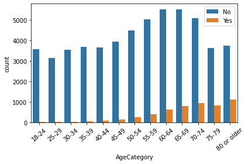

```python
# Biểu đồ:
age_cat = data[['AgeCategory', 'HeartDisease']]
sns.countplot(x='AgeCategory', hue='HeartDisease', data=age_cat, order=age_cat['AgeCategory'].value_counts().index.sort_values())
plt.legend(['No', 'Yes'])
plt.xticks(rotation=40)
plt.tight_layout()
plt.show()
```

```
Biểu đồ hộp thể hiện quan hệ giữa số tuổi và tình trạng bệnh tim
```

```
[Text(0, 0.5, 'Age')]
```

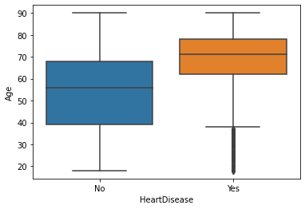

```python
print('Biểu đồ hộp thể hiện quan hệ giữa số tuổi và tình trạng bệnh tim')
axess = sns.boxplot(data=data, x='HeartDisease', y='Age')
axess.set(xlabel='HeartDisease')
axess.set(ylabel='Age')
```

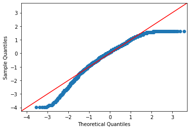

```python
# Biểu đồ qq plot
sm.qqplot(data_Heart.Age, dist=stats.norm, line="45", fit="true")
pylab.show()
```

### Nhận xét: Từ các số liệu và biểu đồ trên ta có thể thấy:

- Tỷ lệ người lớn tuổi (>= 60 tuổi) có nguy cơ mắc bệnh tim cao hơn hẳn so với người trẻ tuổi (< 60 tuổi) là hơn 10%.
- Trung bình độ tuổi của những người bị bệnh tim lớn hơn hẳn so với những người không bị bệnh tim.
- Dựa vào biểu đồ hộp ta có thể thấy có 50% số người bị bệnh tim nằm trong khoảng 63 - 79 tuổi và rất ít người dưới 40 tuổi bị bệnh tim (giá trị ngoại lai).
- Biểu đồ QQplot ta có thể thấy những trường hợp bị bệnh tim khi ở độ tuổi quá thấp hoặc quá cao bị sai lệch khá nhiều nhưng độ tuổi còn lại thì gần như không sai lệch so với đường thẳng QQplot.

```python
# H2: Người có chỉ số khối cơ thể (BMI) cao có khả năng mắc bệnh tim cao hơn.
print('\tThống kê mô tả đối với chỉ số BMI')
data_HeartBMI = data[data.HeartDisease == "Yes"] # Chọn những người bị bệnh tim
data_NoHeartBMI = data[data.HeartDisease == "No"] # Chọn những người ko bị bệnh tim

df_BMI = pd.DataFrame([[data_HeartBMI.BMI.mean(), data_HeartBMI.BMI.median(), data_HeartBMI.BMI.std()],
                        [data_NoHeartBMI.BMI.mean(), data_NoHeartBMI.BMI.median(), data_NoHeartBMI.BMI.std()]],
                        index = ['Heart Disease', 'No Heart Disease'], columns = ['Mean', 'Median', 'StandardDeviation'])
print(df_BMI)
```

```
	Thống kê mô tả đối với chỉ số BMI
                       Mean  Median  StandardDeviation
Heart Disease     29.098400   28.10           6.616839
No Heart Disease  27.975245   26.95           6.275369
```

```
Biểu đồ hộp thể hiện quan hệ giữa chỉ số khối BMI và tình trạng bệnh tim
```

```
[Text(0, 0.5, 'BMI')]
```

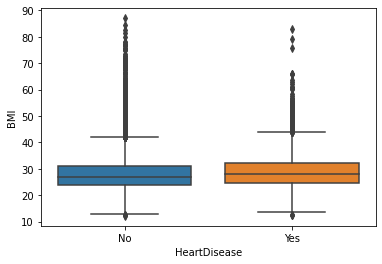

```python
print('Biểu đồ hộp thể hiện quan hệ giữa chỉ số khối BMI và tình trạng bệnh tim')
axess = sns.boxplot(data=data, x='HeartDisease', y='BMI')
axess.set(xlabel='HeartDisease')
axess.set(ylabel='BMI')
```

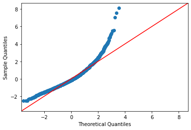

```python
# Biểu đồ qq plot
sm.qqplot(data_Heart.BMI, dist=stats.norm, line="45", fit="true")
pylab.show()
```

### Nhận xét:

- Người bị bệnh tim có trung bình và trung vị chỉ số khối cơ thể (BMI) cao hơn người không bị bệnh tim nhưng không nhiều.
- Dựa vào biểu đồ hộp ta có thể thấy 50% số người bị bệnh tim có số BMI khoảng 25 - 32kg/m2.
- Dựa vào biểu đồ QQplot ta có thể thấy những trường hợp bị bệnh tim khi có BMI quá cao bị sai lệch khá nhiều còn lại thì sai lệch khá ít so với đường thẳng QQPlot.

```python
# H3: Hút thuốc có phải là nguyên nhân dẫn đến bệnh tim nhanh hơn so với uống rượu? - Smoking

data_smoke = data[data['Smoking'] == "Yes"] # Lọc ra những người có hút thuốc
sum_smoke = len((data_smoke).index) #Tổng số người hút thuốc
smoke_Heart = len((data_smoke[data_smoke['HeartDisease'] == "Yes"]).index) # Tổng số người hút thuốc bị bệnh tim
smoke_noHeart = len((data_smoke[data_smoke['HeartDisease'] == "No"]).index) # Tổng số người hút thuốc ko bị bệnh tim

# Tỷ lệ người hút thuốc bị [0] và ko bị[1] bệnh tim
ratio_smoke = (round((smoke_Heart*100)/sum_smoke, 2), round((smoke_noHeart*100)/sum_smoke), 2)


data_alcohol = data[data['AlcoholDrinking'] == "Yes"]
sum_alcohol = len((data_alcohol).index) #Tổng số người uống rượu
alcohol_Heart = len((data_alcohol[data_alcohol['HeartDisease'] == "Yes"]).index) #Tổng số người uống rượu bị bệnh tim
alcohol_noHeart = len((data_alcohol[data_alcohol['HeartDisease'] == "No"]).index) #Tổng số người uống rượu ko bị bệnh tim

# Tỷ lệ người nghiện rượu bị [0] và ko bị[1] bệnh tim
ratio_alcohol = (round((alcohol_Heart*100)/sum_alcohol, 2), round((alcohol_noHeart*100)/sum_alcohol, 2))

df_nghien1 = pd.DataFrame([[smoke_Heart, alcohol_Heart],
                        [smoke_noHeart, alcohol_noHeart]],
                        index = ['Bị bệnh tim', 'Không bị bệnh tim'],
                        columns = ['Tổng số người hút thuốc lá', 'Tổng số người nghiện rượu'])
df_nghien2 = pd.DataFrame([[ratio_smoke[0], ratio_alcohol[0]],
                        [100-ratio_smoke[0], 100 - ratio_alcohol[0]]],
                        index = ['Bị bệnh tim', 'Không bị bệnh tim'],
                        columns = ['Tỷ lệ người hút thuốc lá', 'Tỷ lệ người nghiện rượu'])
```

```python
print('-----Thống kê mô tả ảnh hưởng của việc hút thuốc lá và nghiện rượu tới người mắc bệnh tim-----')
print(df_nghien1)
print('\n', df_nghien2)
```

```
-----Thống kê mô tả ảnh hưởng của việc hút thuốc lá và nghiện rượu tới người mắc bệnh tim-----
                   Tổng số người hút thuốc lá  Tổng số người nghiện rượu
Bị bệnh tim                              3205                        249
Không bị bệnh tim                       22230                       3835

                    Tỷ lệ người hút thuốc lá  Tỷ lệ người nghiện rượu
Bị bệnh tim                            12.6                      6.1
Không bị bệnh tim                      87.4                     93.9
```

```python
def Draw_pie_chart(name_feature):
    fig,axes = plt.subplots(1,2,figsize=(15,8))
    labels = data[name_feature].unique()
    textprops = {"fontsize":15}

    axes[0].pie(data[data['Smoking'] == "Yes"][name_feature].value_counts(), labels=labels,autopct='%1.1f%%',textprops =textprops)
    axes[0].set_title('Tỷ lệ người hút thuốc bị bệnh tim',fontsize=15)
    axes[1].pie(data[data['AlcoholDrinking'] == "Yes"][name_feature].value_counts(), labels=labels,autopct='%1.1f%%',textprops =textprops)
    axes[1].set_title('Tỷ lệ người nghiện rượu bị bệnh tim',fontsize=15)

    plt.legend(title = name_feature, fontsize=15, title_fontsize=15)
    plt.show()
```

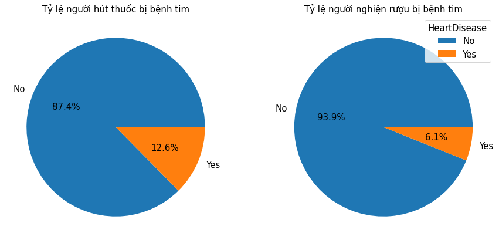

```
NHẬN XÉT: Từ biểu đồ trên ta có thể thấy tỷ lệ những người hút thuốc lá bị bệnh tim cao hơn người nghiện rượu bị bệnh tim.
```

```python
Draw_pie_chart("HeartDisease")
print("NHẬN XÉT: Từ biểu đồ trên ta có thể thấy tỷ lệ những người hút thuốc lá bị bệnh tim cao hơn người nghiện rượu bị bệnh tim.")
```

# Bước 3: Khoảng tin cậy

- Sử dụng khoảng tin cậy 95% để ước lượng khoảng trung bình độ tuổi, trung bình BMI, tỷ lệ giữa người hút thuốc lá và nghiện rượu tới bệnh tim.

```python
confidence = 0.95
t1 = 0
t2 = 0
t3 = 0
t4 = 0
t5 = 0
t6 = 0
t7 = 0
t8 = 0

def mean_confidence_interval(data):
    n = len(data)
    mean, SE = np.mean(data), scipy.stats.sem(data) # trung bình và sai số chuẩn
    sample_SD = stat.stdev(data) # độ lệch chuẩn mẫu
    #t_value
    t_value = stats.t.ppf(1 - (1 - confidence)/2, n-1)
    sampling_dist_mean_SD = sample_SD/math.sqrt(n)
    h = SE * scipy.stats.t.ppf((1 + confidence) / 2, n-1)
    # print((mean-h, mean+h))
    m1 = mean - h
    m2 = mean + h
    return t_value * sampling_dist_mean_SD, m1, m2

def draw_khoang_tin_cay(mean_lt, error_lt, labels):
    fig = plt.figure(figsize=(10,10))
    plt.errorbar(x=mean_lt, y=range(0,len(mean_lt)), xerr=error_lt, fmt='o', color='k')
    plt.yticks([0,1],labels=labels)
    plt.grid(linewidth=1)
    plt.show();

data_Heart_error, t1, t2 = mean_confidence_interval(data_Heart.Age)
data_NoHeart_error, t3, t4 = mean_confidence_interval(data_NoHeart.Age)
error_lt = [data_Heart_error, data_NoHeart_error]
mean_lt = [stat.mean(data_Heart.Age), stat.mean(data_NoHeart.Age)]
labels = ["Khoảng tin cậy\n Heart Disease","Khoảng tin cậy\n No Heart Disease"]

data_HeartBMI_error, t5, t6 = mean_confidence_interval(data_Heart.BMI)
data_NoHeartBMI_error, t7, t8 = mean_confidence_interval(data_NoHeart.BMI)
error_lt = [data_HeartBMI_error, data_NoHeartBMI_error]
mean_lt = [stat.mean(data_Heart.BMI), stat.mean(data_NoHeart.BMI)]
labels = ["Khoảng tin cậy\n Heart Disease","Khoảng tin cậy\n No Heart Disease"]
```

```
	Ước lượng giá trị trung bình của độ tuổi
Trung bình độ tuổi của người bị bệnh tim nằm trong khoảng: ( 68.85099626383449 , 69.5382130384911 )
Trung bình độ tuổi của người không bị bệnh tim nằm trong khoảng: ( 53.82463568801708 , 54.132307103744935 )
```

[figure not shown]

```python
print("\tƯớc lượng giá trị trung bình của độ tuổi")
print("Trung bình độ tuổi của người bị bệnh tim nằm trong khoảng: (", t1, ",", t2, ")")
print("Trung bình độ tuổi của người không bị bệnh tim nằm trong khoảng: (", t3, ",", t4, ")")
draw_khoang_tin_cay(mean_lt,error_lt,labels)
```

```
	Ước lượng giá trị trung bình của chỉ số khối cơ thể
Trung bình chỉ số khối của người bị bệnh tim nằm trong khoảng: ( 28.921467646046416 , 29.27533235395358 )
Trung bình chỉ số khối của người không bị bệnh tim nằm trong khoảng: ( 27.922619290507708 , 28.027871510407618 )
```

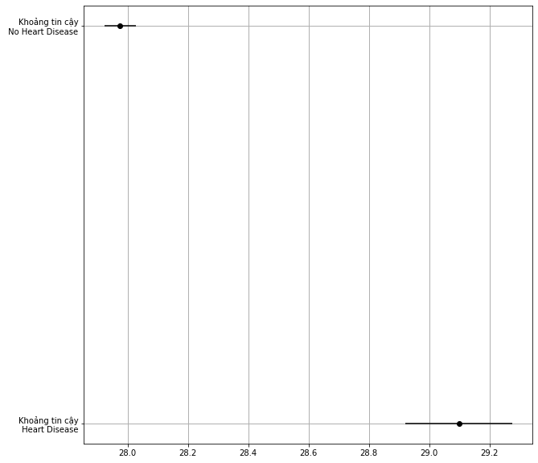

```python
print("\tƯớc lượng giá trị trung bình của chỉ số khối cơ thể")
print("Trung bình chỉ số khối của người bị bệnh tim nằm trong khoảng: (", t5, ",", t6, ")")
print("Trung bình chỉ số khối của người không bị bệnh tim nằm trong khoảng: (", t7, ",", t8, ")")
draw_khoang_tin_cay(mean_lt,error_lt,labels)
```

```python
z_value = norm.ppf(0.975)
#Tính khoảng tin cậy tỉ lệ cho smoking_heart
p_smoking_heart = ratio_smoke[0]/100
smoking_heart_SE = math.sqrt((p_smoking_heart*(1 - p_smoking_heart))/smoke_Heart)
smoking_heart_error = smoking_heart_SE*z_value

#Tính khoảng tin cậy tỉ lệ cho alcohol_heart
p_alcohol_heart = ratio_alcohol[0]/100
alcohol_heart_SE = math.sqrt((p_alcohol_heart*(1 - p_alcohol_heart))/alcohol_Heart)
alcohol_heart_error = alcohol_heart_SE*z_value

data_dict = {}
data_dict['category'] = ['smoke_Heart', 'alcohol_Heart']
data_dict['left'] = [p_smoking_heart - smoking_heart_error, p_alcohol_heart - alcohol_heart_error]
data_dict['right'] = [p_smoking_heart + smoking_heart_error, p_alcohol_heart + alcohol_heart_error]
dataset = pd.DataFrame(data_dict)
```

```
Tỉ lệ người hút thuốc bị bệnh tim nằm trong khoảng: ( 0.11451118958309132 ,  0.13748881041690866 )
Tỉ lệ người nghiện rượu bị bệnh tim nằm trong khoảng: ( 0.031273338958624525 ,  0.09072666104137547 )
```

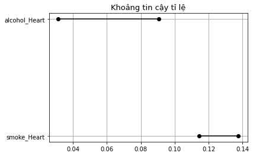

```python
for lower,upper,y in zip(dataset['left'],dataset['right'],range(len(dataset))):
    plt.plot((lower,upper),(y,y), 'o-', color='black')
plt.yticks(range(len(dataset)),list(dataset['category']))
plt.title('Khoảng tin cậy tỉ lệ', color = 'black', fontsize = 13)
plt.grid(linewidth=1)

print('Tỉ lệ người hút thuốc bị bệnh tim nằm trong khoảng: (', data_dict['left'][0], ', ', data_dict['right'][0], ')')
print('Tỉ lệ người nghiện rượu bị bệnh tim nằm trong khoảng: (', data_dict['left'][1], ', ', data_dict['right'][1], ')')
```

### Nhận xét:

Dựa vào khoảng tin cậy 95% ta có thể thấy rằng:

- Trung bình của độ tuổi người bị bệnh tim (68.85, 69.54) lớn hơn so với người không bị bệnh tim (53.82, 54.13).
- Trung bình của chỉ số BMI người bị bệnh tim (28.92, 29.28) chênh lệch không nhiều so với người không bị bệnh tim (27.92, 28.03).
- Tỷ lệ người hút thuốc lá bị bệnh tim (0.1145, 0.1375) cao hơn hẳn so với tỷ lệ người nghiện rượu bị bệnh tim (0.0313, 0.0907).

# Bước 4: Kiểm định ý nghĩa thống kê

- H1: Người lớn tuổi có khả năng mắc bệnh tim cao hơn người trẻ tuổi.
- H2: Người có chỉ số khối cơ thể (BMI) cao có khả năng mắc bệnh tim cao hơn.
- H3: Người hút thuốc lá có khả năng mắc bệnh tim cao hơn so với người nghiện uống rượu.

```python
ageLon_Heart0 = data_ageLon[data_ageLon.HeartDisease == "Yes"] # Người lớn tuổi bị bệnh tim
ageNho_Heart0 = data_ageNho[data_ageNho.HeartDisease == "Yes"] # Người nhỏ tuổi bị bệnh tim

print("H0: Khả năng mắc bệnh tim của người cao tuổi và người trẻ tuổi là như nhau")
print("H1: Người lớn tuổi có khả năng mắc bệnh tim cao hơn người trẻ tuổi")
t_stat, p = stats.ttest_ind(ageLon_Heart0.Age, ageNho_Heart0.Age)
print(f"Giá trị p tính được là kiểm định hai phía: p = {p}")
print(f"Vì giả thuyết là kiểm định một phía nên giá trị p = p / 2 = {p} / 2 = {p/2}")
p = p / 2
print(f"Ta có p_value = {p} < 0.05 ==> Ta có thể bác bỏ H0 và chấp nhận H1")
```

```
H0: Khả năng mắc bệnh tim của người cao tuổi và người trẻ tuổi là như nhau
H1: Người lớn tuổi có khả năng mắc bệnh tim cao hơn người trẻ tuổi
Giá trị p tính được là kiểm định hai phía: p = 0.0
Vì giả thuyết là kiểm định một phía nên giá trị p = p / 2 = 0.0 / 2 = 0.0
Ta có p_value = 0.0 < 0.05 ==> Ta có thể bác bỏ H0 và chấp nhận H1
```

```python
print("H0: người bị bệnh tim hay không bị đều có chỉ số khối như nhau.")
print("H2: Người có chỉ số khối cơ thể (BMI) cao có khả năng mắc bệnh tim cao hơn.")
t_stat, p = stats.ttest_ind(data_Heart.BMI, data_NoHeart.BMI)
print(f"Giá trị p tính được là kiểm định hai phía: p = {p}")
print(f"Vì giả thuyết là kiểm định một phía nên giá trị p = p / 2 = {p} / 2 = {p/2}")
p = p / 2
print(f"Ta có p_value = {p} < 0.05 ==> Ta có thể bác bỏ H0 và chấp nhận H2")
```

```
H0: người bị bệnh tim hay không bị đều có chỉ số khối như nhau.
H2: Người có chỉ số khối cơ thể (BMI) cao có khả năng mắc bệnh tim cao hơn.
Giá trị p tính được là kiểm định hai phía: p = 1.401261598207498e-35
Vì giả thuyết là kiểm định một phía nên giá trị p = p / 2 = 1.401261598207498e-35 / 2 = 7.00630799103749e-36
Ta có p_value = 7.00630799103749e-36 < 0.05 ==> Ta có thể bác bỏ H0 và chấp nhận H2
```

```python
total_heart = smoke_Heart + alcohol_Heart
total_NoHeart = smoke_noHeart + alcohol_noHeart
total = total_heart + total_NoHeart

def tinhKyVong(total_r, total_c, total):
    return (total_r*total_c)/total

smoke_Heart_ex = tinhKyVong(sum_smoke, total_heart, total)
smoke_NoHeart_ex = tinhKyVong(sum_smoke, total_NoHeart, total)
alcohol_Heart_ex = tinhKyVong(sum_alcohol, total_heart, total)
alcohol_NoHeart_ex = tinhKyVong(sum_alcohol, total_NoHeart, total)

total_heart_ex = smoke_Heart_ex + alcohol_Heart_ex
total_NoHeart_ex = smoke_NoHeart_ex + alcohol_NoHeart_ex
total_ex = total_heart_ex + total_NoHeart_ex

def chi_squared(obs, exp):
    return ((obs - exp)**2)/exp

squared = chi_squared(smoke_Heart, smoke_Heart_ex) + chi_squared(smoke_noHeart, smoke_NoHeart_ex) + chi_squared(alcohol_Heart, alcohol_Heart_ex) + chi_squared(alcohol_noHeart, alcohol_NoHeart_ex)
p_value = 1 - stats.chi2.cdf(squared, 1)
```

```python
print("H0: Người hút thuốc lá có khả năng mắc bệnh tim ngang bằng so với người nghiện uống rượu.")
print("H3: Người hút thuốc lá có khả năng mắc bệnh tim cao hơn so với người nghiện uống rượu.")

if (p_value > 0.05):
    print(f"\nTa có p_value = {p_value} > 0.05 ==> Ta chấp nhận H0")
else:
    print(f"\nTa có p_value = {p_value} < 0.05 ==> Ta bác bỏ H0, chấp nhận H3")
```

```
H0: Người hút thuốc lá có khả năng mắc bệnh tim ngang bằng so với người nghiện uống rượu.
H3: Người hút thuốc lá có khả năng mắc bệnh tim cao hơn so với người nghiện uống rượu.

Ta có p_value = 0.0 < 0.05 ==> Ta bác bỏ H0, chấp nhận H3
```

# Phần 3 - Kết luận

- Sau khi phân tích và kiểm định, chúng em đã có bằng chứng chỉ ra rằng những người có độ tuổi càng cao thì sẽ có tỉ lệ mắc bệnh tim cao hơn những người có độ tuổi thấp hơn, những người có chỉ số khối cơ thể (BMI) cao sẽ có nguy cơ bị bệnh tim cao hơn những người có chỉ số BMI thấp. Đặc biệt hơn, bộ dữ liệu của chúng em chỉ xét những người đã hút ít nhất 5 gói thuốc lá trong cuộc đời, còn người nghiện rượu thì xét tới những người uống hằng tuần nhưng đã cho thấy người hút thuốc lá có nguy cơ mắc bệnh tim cao hơn. Vậy nên ta có thể kết luận người hút thuốc lá có nguy cơ mắc bệnh tim cao hơn rất nhiều so với người uống rượu.
- Do nghiên cứu chúng em thực hiện chỉ là nghiên cứu quan sát nên chỉ có thể kết luận sự khác biệt chứ không thể đưa ra kết luận chính xác, vì còn phụ thuộc nhiều vào các biến ẩn khác.
- Nhóm chúng em chọn tập dữ liệu trên kaggle và tập dữ liệu này được lấy từ khảo sát trực tuyến nên những người tham gia có thể bị ảnh hưởng bởi nhiều yếu tố chủ quan làm tập dữ liệu có nhiều sai sót.
- Sự hiểu biết và thời gian có hạn nên bài báo cáo vẫn còn nhiều lỗi. Nếu nhóm em có nhiều thời gian hơn thì nhóm em sẽ thay đổi phương pháp chọn mẫu để có kết quả khách quan hơn và tìm ra thêm nhiều biến ẩn ảnh hưởng đến bệnh tim để kết quả cuối cùng có thể chính xác hơn.